# Analyzing What's Important in CS:GO

## By: Daniel Chen and Teddy Popescu

[figure not shown]

### Full squad of 5 Counter-Terrorists

Counter-Strike: Global Offensive (CS:GO) is a multiplayer first person shooter game developed by Valve. CS:GO was one of the most popular first person shooter games at the time of its release in 2012, and remains popular today, routinely achieving daily peak player totals above 1 million. In CS:GO there are two teams of 5 players each, the attacking “terrorists” and the defending “counter-terrorists”.

In our tutorial, we used game data scraped from games played on ESEA’ servers. ESEA is a platform that hosts games as a third-party to Valve’s matchmaking service that promotes a more secure anti-cheating program. We aim to use this data to examine which weapons are most successful in winning rounds and killing opponents, analyze how much the overall team’s economy has an effect in them winning a round, and compare how the map that is played has an overall impact on the match. Through these analyses we want to gain insights on the strategies that are used to win gunfights and win rounds, and try to make a model that can accurately predict which side will win a given round. We hope that through this tutorial we are able to provide interesting insights on the important factors to winning in CS:GO, and motivate people to try and pick up the game.

```python
import pandas as pd
import math
import numpy as np
from numpy import array
import matplotlib.pyplot as plt
from scipy.stats import f
import seaborn as sns
from sklearn.metrics import mean_squared_error
from sklearn import model_selection
from sklearn import linear_model
from sklearn import preprocessing
from sklearn.model_selection import train_test_split
from sklearn.linear_model import LinearRegression
from sklearn.preprocessing import LabelEncoder
from scipy.stats import binom
from matplotlib.ticker import PercentFormatter
import statsmodels.formula.api as smf
from IPython.display import Image
import warnings
warnings.filterwarnings('ignore')
```

```python
# Centering all images and changing font to Times New Roman
from IPython.core.display import HTML
HTML("""
<style>
.output_png {
    display: table-cell;
    text-align: center;
    vertical-align: middle;
}
</style>
""")
HTML("""
<style>
.text_cell_render {
font-family: Times New Roman, serif;
}
</style>
""")
```

We are using Python 3. We decided to use libraries like pandas and numpy to help us display the csv's and tidy them. We also chose libraries such as seaborn and matplotlib to create graphs of our data.

First, we picked out certain csv files that we believed would be the most helpful for our project and we picked out a dataset for round times/economy. This dataset also gives us what type of round the winning side had during said round. We named this dataset "round_data". The second csv dataset gives us crucial kill data, and each row in this csv represents a kill during a round. The dataset also gives us information about whether the bomb was planted and what weapons were used to get kills.

We have a set of round and kill data that are synchronized with each other and we split it up so that we can see any trends that are present.

```python
# loading csv files into separate dataframes
round_data = pd.read_csv("esea_meta_demos.part1.csv", sep=',')
kills = pd.read_csv("esea_master_kills_demos.part1.csv", sep=',')
maps = pd.read_csv("esea_meta_demos.part1.csv", sep=',')
round_data
```

|  | file | map | round | start_seconds | end_seconds | winner_team | winner_side | round_type | ct_eq_val | t_eq_val |
| --- | --- | --- | --- | --- | --- | --- | --- | --- | --- | --- |
| 0 | esea_match_13770997.dem | de_overpass | 1 | 94.30782 | 160.9591 | Hentai Hooligans | Terrorist | PISTOL_ROUND | 4300 | 4250 |
| 1 | esea_match_13770997.dem | de_overpass | 2 | 160.95910 | 279.3998 | Hentai Hooligans | Terrorist | ECO | 6300 | 19400 |
| 2 | esea_match_13770997.dem | de_overpass | 3 | 279.39980 | 341.0084 | Hentai Hooligans | Terrorist | SEMI_ECO | 7650 | 19250 |
| 3 | esea_match_13770997.dem | de_overpass | 4 | 341.00840 | 435.4259 | Hentai Hooligans | Terrorist | NORMAL | 24900 | 23400 |
| 4 | esea_match_13770997.dem | de_overpass | 5 | 435.42590 | 484.2398 | Animal Style | CounterTerrorist | ECO | 5400 | 20550 |
| ... | ... | ... | ... | ... | ... | ... | ... | ... | ... | ... |
| 215914 | esea_match_13793043.dem | de_cache | 14 | 1062.96100 | 1129.0460 | Team 2 | Terrorist | NORMAL | 28400 | 25800 |
| 215915 | esea_match_13793043.dem | de_cache | 15 | 1129.04600 | 1185.9160 | Team 1 | CounterTerrorist | FORCE_BUY | 13150 | 25550 |
| 215916 | esea_match_13793043.dem | de_cache | 16 | 1221.13300 | 1288.4690 | Team 2 | CounterTerrorist | PISTOL_ROUND | 4200 | 4250 |
| 215917 | esea_match_13793043.dem | de_cache | 17 | 1288.46900 | 1342.4450 | Team 2 | CounterTerrorist | SEMI_ECO | 18300 | 8200 |
| 215918 | esea_match_13793043.dem | de_cache | 18 | 1342.44500 | 1412.6290 | Team 2 | CounterTerrorist | SEMI_ECO | 24400 | 9950 |

215919 rows × 10 columns

In the above round_data dataset, there are 10 columns. Each column represents:

- File: The name of the demo file
- Map: What map was being played
- Round: What round the data corresponds to (each row represents a round)
- Start_Seconds: What second the round started at
- End_Seconds: What second the round ended at
- Winner_Team: Which team (team name) won the round
- Winner_Side: Which side (Terrorist/Counter Terrorist) won the round
- Round_Type: What kind of round (Pistol, Eco, Semi-Eco, Normal, Force Buy) the winning side had
- CT_Eq_Val: Counter Terrorist total equpiment value (guns, armor, grenades)
- T_Eq_Val: Terrorist total equpiment value (guns, armor, grenades)

```python
kills
```

|  | file | round | tick | seconds | att_team | vic_team | att_side | vic_side | wp | wp_type | ct_alive | t_alive | is_bomb_planted |
| --- | --- | --- | --- | --- | --- | --- | --- | --- | --- | --- | --- | --- | --- |
| 0 | esea_match_13770997.dem | 1 | 16058 | 30.74165 | Animal Style | Hentai Hooligans | CounterTerrorist | Terrorist | USP | Pistol | 5 | 4 | False |
| 1 | esea_match_13770997.dem | 1 | 16210 | 31.93185 | Hentai Hooligans | Animal Style | Terrorist | CounterTerrorist | Glock | Pistol | 4 | 4 | False |
| 2 | esea_match_13770997.dem | 1 | 16510 | 34.28094 | Hentai Hooligans | Animal Style | Terrorist | CounterTerrorist | Glock | Pistol | 3 | 4 | False |
| 3 | esea_match_13770997.dem | 1 | 17104 | 38.93212 | Animal Style | Hentai Hooligans | CounterTerrorist | Terrorist | USP | Pistol | 3 | 3 | False |
| 4 | esea_match_13770997.dem | 1 | 17338 | 40.76441 | Hentai Hooligans | Animal Style | Terrorist | CounterTerrorist | Glock | Pistol | 2 | 3 | False |
| ... | ... | ... | ... | ... | ... | ... | ... | ... | ... | ... | ... | ... | ... |
| 1569472 | esea_match_13793043.dem | 18 | 178305 | 50.64319 | Team 2 | Team 2 | CounterTerrorist | CounterTerrorist | Swag7 | Heavy | 3 | 2 | False |
| 1569473 | esea_match_13793043.dem | 18 | 178463 | 51.87915 | Team 1 | Team 2 | Terrorist | CounterTerrorist | CZ | Pistol | 2 | 2 | True |
| 1569474 | esea_match_13793043.dem | 18 | 178719 | 53.88171 | Team 1 | Team 2 | Terrorist | CounterTerrorist | Deagle | Pistol | 1 | 2 | True |
| 1569475 | esea_match_13793043.dem | 18 | 178905 | 55.33667 | Team 2 | Team 1 | CounterTerrorist | Terrorist | Swag7 | Heavy | 1 | 1 | True |
| 1569476 | esea_match_13793043.dem | 18 | 179955 | 63.55042 | Team 2 | Team 1 | CounterTerrorist | Terrorist | Swag7 | Heavy | 1 | 0 | True |

1569477 rows × 13 columns

In the above kills dataset, there are 13 columns. Each column represents:

- File: The name of the demo file
- Round: What round the data corresponds to
- Tick: How long each round lasted in terms of server refresh data
- Seconds: What second the kill was recorded at
- Att_Team: Which team (Team 1 or 2) was attacking
- Vic_Side: Which side suffered the death of one of their players
- Wp: What weapon was used to kill the player
- Wp_Type: What type of weapon the specified gun is
- Ct_alive: How many Counter Terrorists are alive after the kill
- T_alive: How many Terrorists are alive after the kill
- Is_bomb_planted: Binary representation of whether the bomb is planted at the instant of the kill

```python
kills.drop(['tick'], axis=1, inplace=True)
```

We decided to drop tick because we have seconds to measure the length of a round and with tick, it's difficult to read and serves no additional purpose since we have seconds.

## Map: de_mirage

[figure not shown]

## Graphing Weapon Kill Output

With the different properties of each weapon class, it is important to see how often each one is used during a match to see if any weapon class has an advantage or disadvantage.

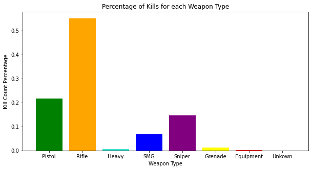

```python
wep_type = []
count = []
colors = ["green", "orange", "turquoise", "blue", "purple", "yellow", "red", "pink"]
x = 0

# iterating through all unique weapon types
for weapon in kills["wp_type"].unique():
    # appending weapon type to x-axis
    wep_type.append(weapon)
    # appending the amount of kills present in the dataframe by that weapon type / number of kills to output percentage
    count.append(kills['wp_type'].value_counts()[weapon] / len(kills.index))
plt.figure(figsize = (10,5))
plt.bar(wep_type, count, color=colors)
plt.title('Percentage of Kills for each Weapon Type')
plt.xlabel('Weapon Type')
plt.ylabel('Kill Count Percentage')
plt.show()
```

This graph shows the percentage of all kills logged in our dataframe that were attributed to each weapon type. For general understanding, the Equipment and Unknown bars in this graph can be ignored, as the “weapons” in these categories only produce kills in extremely rare circumstances, and the purpose of these “weapons” is not to get a kill. Through this graph, we can see that over 50 percent of kills were registered with some kind of rifle. This is over double the amount of the next closest weapon type, that being the pistol. On the other end, the heavy (shotgun) weapon type is used an extremely small amount of the time. Although this graph is good at demonstrating the general trend of which type of weapons are mostly used by players, it does not take into account the different scenarios surrounding each round in the game.

In a game of Counter-Strike, there are 30 rounds, with the first team to reach 16 winning the game. Throughout the game, each player builds up a certain amount of cash, through events such as winning a round, losing a round, planting the bomb, killing an enemy, etc. The money that a player has accrued is used for them to purchase weapons, with some weapons being easily purchased, and others being more expensive. When a team does not have enough money to buy their primary weapons of choice, a popular strategy is for that team to “save” their money, purchase very little, in an attempt to be able to purchase those weapons next round.

Therefore a round in CS:GO can be characterized in many ways: a “normal” round, where a team has enough money to buy their desired weapons, “eco” round, where a team buys next to nothing, “semi-eco” where a team purchases some weapons, but very little, and a “force-buy” round where a team does not have the necessary money to buy what they want, but spends all of their available money anyway. On top of this, there is the beginning “pistol” round where both teams begin the game with little money, and only have money to purchase pistols. Therefore, we want to observe the most commonly used weapons for each round type in CS:GO.

In each weapon category, the difference in price for each individual weapon is very small and does not greatly impact weapon choice inside of a given category, so we will first see which weapons are most commonly used inside each weapon class, and see how the usage of those most popular weapons changes depending on round.

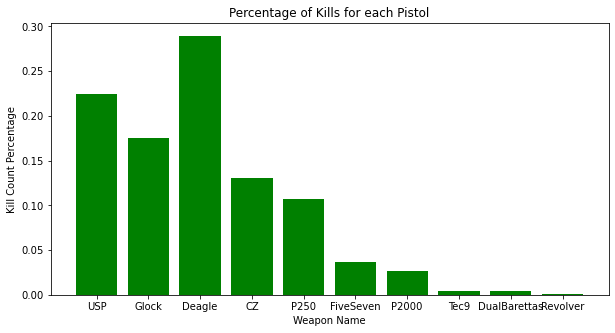

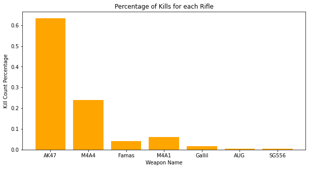

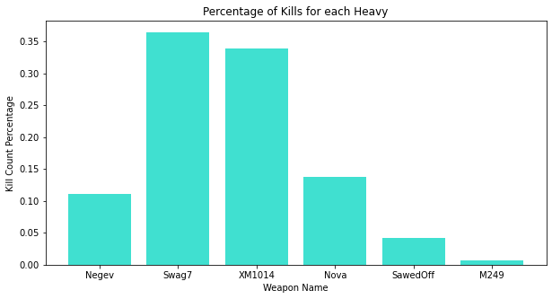

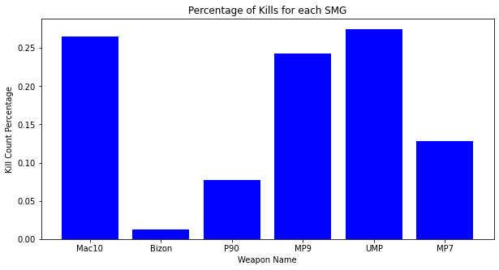

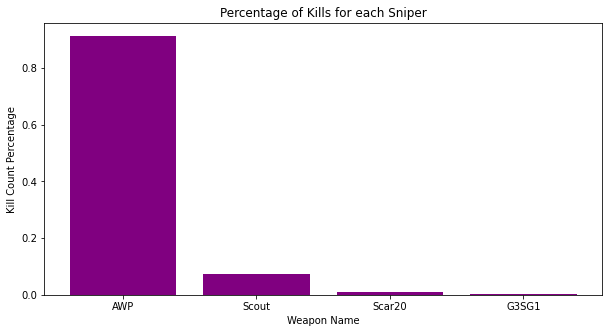

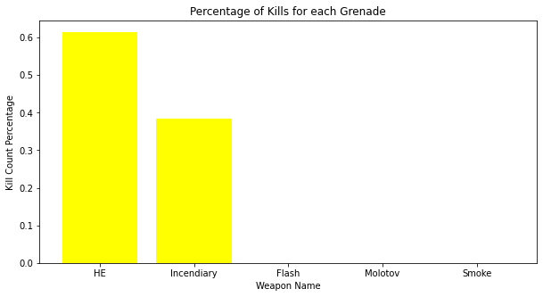

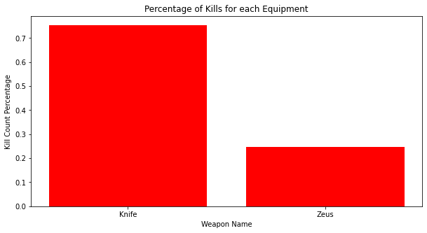

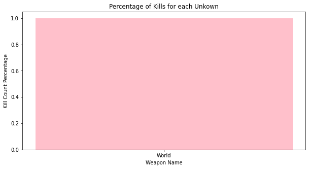

```python
weapons = []
count = []
x = 0

# iterating through each unique weapon type
for weapon in kills["wp_type"].unique():
    # array to store each specific weapon for x-axis
    wep_type = []
    # array to store how many kills done by each specific weapon
    count = []
    # in each unique weapon type, we iterate through each specific weapon
    for specific in kills[kills["wp_type"] == weapon]["wp"].unique():
        # append the specific weapon to array
        wep_type.append(specific)
        # append the amount of kills done by the weapon / total kills done by the parent weapon type
        count.append(kills['wp'].value_counts()[specific] / kills['wp_type'].value_counts()[weapon])
    plt.figure(figsize = (10,5))
    plt.bar(wep_type, count, color=colors[x])
    plt.title('Percentage of Kills for each ' + weapon)
    plt.xlabel('Weapon Name')
    plt.ylabel('Kill Count Percentage')
    plt.show()
    x += 1
```

These graphs show each weapons’ percentage of kills in their weapon category, and through these graphs we can see the weapons that are most popularly used in each category. Despite being in the same class, some weapons are clearly used at higher rates than others, this is due to each weapon having slightly different characteristics to the others in its class, that players may find useful, such as some rifles having a scope to allow a player to zoom in. We discount the Equipment and Unknown weapon types due to the prior reasoning. Grenades are a weapon type that is very cheap in game, and is purchasable in every round type. As a result, we also discounted Grenades from our by-round analysis. To determine the popularity of the weapon, we selected any weapon that accounted for above 15 percent of its weapon type’s kills to be included.

```python
# make round_type column inside of kills dataframe
counter = 0
counter2 = 0
counter3 = 0
kills["round_type"] = " "

# itearting through each row in round_data
for row in round_data.index:
    # at the first row, just append normally
    if row == 0:
        kills.at[counter2, "round_type"] = round_data.at[counter, "round_type"]
        counter2 += 1

    # due to a round being randomly dropped, we need to add it back in
    else:
        if kills.at[counter2, "round"] == 16 and counter3 < 6:
            kills.at[counter2, "round_type"] = "PISTOL_ROUND"
            counter2 += 1
            counter3 += 1
        else:
            if kills.at[counter2 - 1, "round"] != kills.at[counter2, "round"]:
                counter += 1
                kills.at[counter2, "round_type"] = round_data.at[counter, "round_type"]
                counter2 += 1
            else:
                kills.at[counter2, "round_type"] = round_data.at[counter, "round_type"]
                counter2 += 1

kills
```

|  | file | round | seconds | att_team | vic_team | att_side | vic_side | wp | wp_type | ct_alive | t_alive | is_bomb_planted | round_type |
| --- | --- | --- | --- | --- | --- | --- | --- | --- | --- | --- | --- | --- | --- |
| 0 | esea_match_13770997.dem | 1 | 30.74165 | Animal Style | Hentai Hooligans | CounterTerrorist | Terrorist | USP | Pistol | 5 | 4 | False | PISTOL_ROUND |
| 1 | esea_match_13770997.dem | 1 | 31.93185 | Hentai Hooligans | Animal Style | Terrorist | CounterTerrorist | Glock | Pistol | 4 | 4 | False | PISTOL_ROUND |
| 2 | esea_match_13770997.dem | 1 | 34.28094 | Hentai Hooligans | Animal Style | Terrorist | CounterTerrorist | Glock | Pistol | 3 | 4 | False | PISTOL_ROUND |
| 3 | esea_match_13770997.dem | 1 | 38.93212 | Animal Style | Hentai Hooligans | CounterTerrorist | Terrorist | USP | Pistol | 3 | 3 | False | PISTOL_ROUND |
| 4 | esea_match_13770997.dem | 1 | 40.76441 | Hentai Hooligans | Animal Style | Terrorist | CounterTerrorist | Glock | Pistol | 2 | 3 | False | PISTOL_ROUND |
| ... | ... | ... | ... | ... | ... | ... | ... | ... | ... | ... | ... | ... | ... |
| 1569472 | esea_match_13793043.dem | 18 | 50.64319 | Team 2 | Team 2 | CounterTerrorist | CounterTerrorist | Swag7 | Heavy | 3 | 2 | False |  |
| 1569473 | esea_match_13793043.dem | 18 | 51.87915 | Team 1 | Team 2 | Terrorist | CounterTerrorist | CZ | Pistol | 2 | 2 | True |  |
| 1569474 | esea_match_13793043.dem | 18 | 53.88171 | Team 1 | Team 2 | Terrorist | CounterTerrorist | Deagle | Pistol | 1 | 2 | True |  |
| 1569475 | esea_match_13793043.dem | 18 | 55.33667 | Team 2 | Team 1 | CounterTerrorist | Terrorist | Swag7 | Heavy | 1 | 1 | True |  |
| 1569476 | esea_match_13793043.dem | 18 | 63.55042 | Team 2 | Team 1 | CounterTerrorist | Terrorist | Swag7 | Heavy | 1 | 0 | True |  |

1569477 rows × 13 columns

We did not have round_data inside of our kills database, so we made a new column for round type. Our round_data dataset is synced up with our kills dataset with the first game in the kills dataset also being the first game in the round data dataset and etc. What we did was we manually matched up the correct round type to each kill by going through each dataset, and setting the round type for each kill in the kills dataset to the equivalent round type for that round in the round_data dataset. Some round types are blank because there were additional games in the kills dataset, so some of the later kills do not have a round type due to the slight difference in dataset sizes.

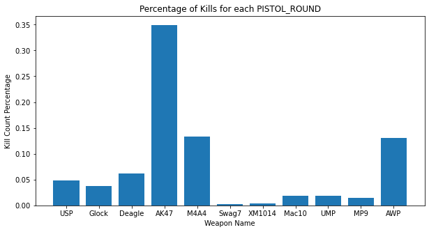

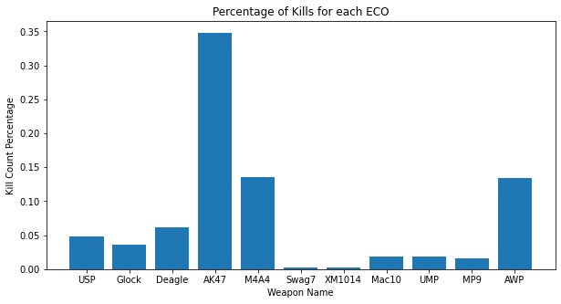

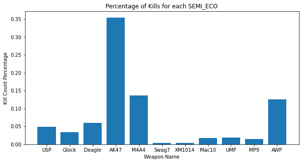

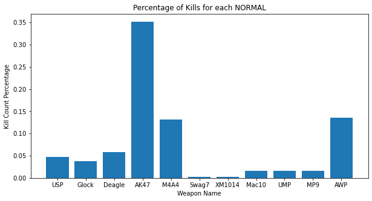

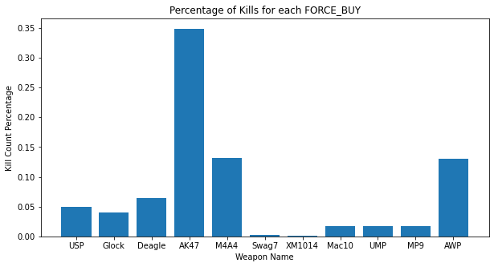

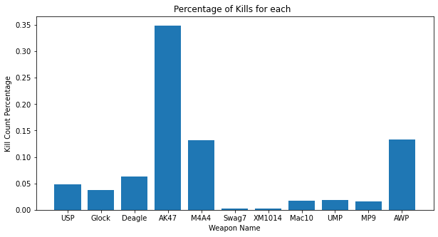

```python
weapons = ["USP", "Glock", "Deagle", "AK47", "M4A4", "Swag7", "XM1014", "Mac10", "UMP", "MP9", "AWP"]
temp = []
r = 0

# iterating through each unique round type
for roundtype in kills["round_type"].unique():
    count = []
    # iterating through each weapon in weapons array
    for weapon in weapons:
        # append number of kills done by each weapon divided by total number of kills done in that specific round type
        count.append(kills[kills["round_type"] == roundtype]['wp'].value_counts()[weapon] / kills['round_type'].value_counts()[roundtype])
    temp.append(count)
    plt.figure(figsize = (10,5))
    plt.bar(weapons, temp[r])
    plt.title('Percentage of Kills for each ' + roundtype)
    plt.xlabel('Weapon Name')
    plt.ylabel('Kill Count Percentage')
    r += 1
    plt.show()
```

These results are not possible, demonstrated by the fact that in a Pistol Round, weapons like an AWP and an AK-47 cannot be purchased as they are wildly more expensive the money that players start a game with. This seems to be due to several missing rounds in the round database, which despite us trying to account for when spotting some of these skipped rounds, it is impossible for us to account for all of these inconsistencies, and this resulted in some rounds being misclassified. Therefore we cannot conclude any findings regarding weapon usage in different rounds, due to slightly misaligned database errors.

Our final conclusions regarding weapons in CS:GO, despite not being able to make any statements regarding specific rounds, is that rifles, in particular the AK-47, were overwhelmingly used more in getting kills in games. This is supported by the fact that the AK-47 is only available on the terrorist side, which given it’s more limited availability when compared to other weapons that are always available, shows that the AK-47 was used near exclusively by the terrorist side. On top of this, the heavy class was used incredibly sparingly, with the highest shotgun kill percentage being the Swag7 at less than 1 percent, which is on par with the lowest rifle kill percentage (SG 553). FInally, for each weapon class, although there were clear favorites among players, there seemed to be good balance, with usually 2-3 weapons from each class seeing significant usage.

## Map: de_dust2

[figure not shown]

## Predicting Round Win/Loss based on Round Characteristics

Kills play a massive part in determining who wins the round/match in CS:GO. One of the win conditions for both sides is eliminating the whole enemy side, and kills enable each side to more easily complete their round objective to win. Despite this, kills are not the only factor when it comes to determining who wins a round. Other factors, such as how long the round took, how much money each team had to begin the round, which side the team is on, and whether the bomb was planted during the round play a crucial role as well. We aim to use these many factors to help create a model that can accurately predict round win/loss.

### Round Time

There is a timer for each round in Counter-Strike, and each round takes a certain amount of seconds from the round start to the round end. There are several phases to a counter-strike round, starting with a 15 second “freeze time” period where teams can purchase their weapons and equipment. The “main round” has a 1 minute and 55 second timer, where if the terrorist side cannot eliminate the counter-terrorist side or plant the bomb, then they lose the round and the round ends. If the bomb is planted at any point, the round shifts to a “post-plant” phase, where there are 40 seconds for the counter-terrorists to try and defuse the bomb. Regardless of if the round enters the post-plant phase or not, there is a 3-5 second ending phase after the round result has been decided before the next round starts. As a result of the round timer that the terrorist team must work in, there are many different strategies for the terrorist side to try and win the round, from taking their time in planting the bomb, to trying to immediately start fighting. We want to try and see the optimal round time taken to win a round as the terrorist side.

```python
# creating total round time column
round_data["total_time"] = round_data["end_seconds"] - round_data["start_seconds"]
round_data
```

|  | file | map | round | start_seconds | end_seconds | winner_team | winner_side | round_type | ct_eq_val | t_eq_val | total_time |
| --- | --- | --- | --- | --- | --- | --- | --- | --- | --- | --- | --- |
| 0 | esea_match_13770997.dem | de_overpass | 1 | 94.30782 | 160.9591 | Hentai Hooligans | Terrorist | PISTOL_ROUND | 4300 | 4250 | 66.65128 |
| 1 | esea_match_13770997.dem | de_overpass | 2 | 160.95910 | 279.3998 | Hentai Hooligans | Terrorist | ECO | 6300 | 19400 | 118.44070 |
| 2 | esea_match_13770997.dem | de_overpass | 3 | 279.39980 | 341.0084 | Hentai Hooligans | Terrorist | SEMI_ECO | 7650 | 19250 | 61.60860 |
| 3 | esea_match_13770997.dem | de_overpass | 4 | 341.00840 | 435.4259 | Hentai Hooligans | Terrorist | NORMAL | 24900 | 23400 | 94.41750 |
| 4 | esea_match_13770997.dem | de_overpass | 5 | 435.42590 | 484.2398 | Animal Style | CounterTerrorist | ECO | 5400 | 20550 | 48.81390 |
| ... | ... | ... | ... | ... | ... | ... | ... | ... | ... | ... | ... |
| 215914 | esea_match_13793043.dem | de_cache | 14 | 1062.96100 | 1129.0460 | Team 2 | Terrorist | NORMAL | 28400 | 25800 | 66.08500 |
| 215915 | esea_match_13793043.dem | de_cache | 15 | 1129.04600 | 1185.9160 | Team 1 | CounterTerrorist | FORCE_BUY | 13150 | 25550 | 56.87000 |
| 215916 | esea_match_13793043.dem | de_cache | 16 | 1221.13300 | 1288.4690 | Team 2 | CounterTerrorist | PISTOL_ROUND | 4200 | 4250 | 67.33600 |
| 215917 | esea_match_13793043.dem | de_cache | 17 | 1288.46900 | 1342.4450 | Team 2 | CounterTerrorist | SEMI_ECO | 18300 | 8200 | 53.97600 |
| 215918 | esea_match_13793043.dem | de_cache | 18 | 1342.44500 | 1412.6290 | Team 2 | CounterTerrorist | SEMI_ECO | 24400 | 9950 | 70.18400 |

215919 rows × 11 columns

We have the start_seconds column and end_seconds column for each round, so we created a column where we subtracted the start_seconds from end_seconds and that gives us the total_time column.

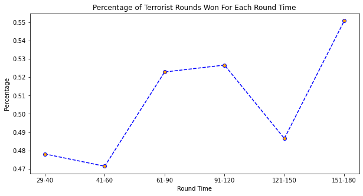

```python
colors = ["green", "orange", "turquoise", "blue", "purple", "red", "yellow", "pink"]
# creating bins for each time stamp
bins = [29, 40, 60, 90, 120, 150, 180]
# categories to group rounds that end in these time ranges
group_names = ['29-40', '41-60', '61-90', "91-120", "121-150", "151-180"]
# tagging each row to its corresponding bin
round_data['categories'] = pd.cut(round_data['total_time'], bins, labels=group_names)
round_data

i = 0
win = "Terrorist"
categories = []
win_loss = []

# each bin to categories array to be graphed
for i in range(0,6):
    categories.append(group_names[i])
    # appending only Terrorist wins for each bin time representation
    win_loss.append(round_data[round_data['categories'] == group_names[i]]["winner_side"].value_counts(win))

filtered_data = pd.DataFrame(win_loss)
plt.figure(figsize = (10,5))
plt.plot(categories, filtered_data[win], linestyle='--', marker='o', color='b', label='line with marker', mfc='orange')
plt.title('Percentage of Terrorist Rounds Won For Each Round Time')
plt.xlabel('Round Time')
plt.ylabel('Percentage')
plt.show()
```

Even though the differences in win percentage are slight, given the large size of our dataset, even these seemingly slight differences are important. From this graph, we can see that terrorists won less than 50 percent of rounds in which the round took a small amount of time, and perform the best when they either took a medium, or very long amount of time in the round. We believe that the reason for the terrorist side’s struggles during shorter rounds is due to the common occurrence of playing a much faster style of round when having little money. This is because when not having proper weapons at your disposal, the common thought is that it is tough to play a more normal pace of round, and therefore many teams elect to “rush” a bombsite to try and either catch the counter-terrorist team off guard, or to end the round quickly and move on to the next where they will have better weaponry.

Additionally, we believe that the dip in terrorist round win-percentage for rounds taking 120-150 seconds, is as a result of terrorists not being able to plant the bomb in the normal round timer, and electing to run out the clock and save their weapons for the next round. This is similar to our reasoning that terrorists are able to win the rounds that are extremely long, as these rounds would not reach these lengths of time without the bomb being planted, which we believe is a very important aspect for terrorists winning a round in CS:GO.

### Bomb Planted

Given that the bomb being planted at a bombsite and defended is one of the win conditions in a round for the terrorist side, we want to see how important planting a bomb is in determining which side wins a round.

```python
counter = 0
counter2 = 0
counter3 = 0
kills["win_side"] = " "

for row in round_data.index:
    if kills.at[counter2, "ct_alive"] == 0 or kills.at[counter2, "t_alive"] == 0:
        kills.at[counter2, "win_side"] = round_data.at[counter, "winner_side"]
        counter2 += 1
        counter += 1
    else:
        counter2 += 1
kills
```

|  | file | round | seconds | att_team | vic_team | att_side | vic_side | wp | wp_type | ct_alive | t_alive | is_bomb_planted | round_type | win_side |
| --- | --- | --- | --- | --- | --- | --- | --- | --- | --- | --- | --- | --- | --- | --- |
| 0 | esea_match_13770997.dem | 1 | 30.74165 | Animal Style | Hentai Hooligans | CounterTerrorist | Terrorist | USP | Pistol | 5 | 4 | False | PISTOL_ROUND |  |
| 1 | esea_match_13770997.dem | 1 | 31.93185 | Hentai Hooligans | Animal Style | Terrorist | CounterTerrorist | Glock | Pistol | 4 | 4 | False | PISTOL_ROUND |  |
| 2 | esea_match_13770997.dem | 1 | 34.28094 | Hentai Hooligans | Animal Style | Terrorist | CounterTerrorist | Glock | Pistol | 3 | 4 | False | PISTOL_ROUND |  |
| 3 | esea_match_13770997.dem | 1 | 38.93212 | Animal Style | Hentai Hooligans | CounterTerrorist | Terrorist | USP | Pistol | 3 | 3 | False | PISTOL_ROUND |  |
| 4 | esea_match_13770997.dem | 1 | 40.76441 | Hentai Hooligans | Animal Style | Terrorist | CounterTerrorist | Glock | Pistol | 2 | 3 | False | PISTOL_ROUND |  |
| ... | ... | ... | ... | ... | ... | ... | ... | ... | ... | ... | ... | ... | ... | ... |
| 1569472 | esea_match_13793043.dem | 18 | 50.64319 | Team 2 | Team 2 | CounterTerrorist | CounterTerrorist | Swag7 | Heavy | 3 | 2 | False |  |  |
| 1569473 | esea_match_13793043.dem | 18 | 51.87915 | Team 1 | Team 2 | Terrorist | CounterTerrorist | CZ | Pistol | 2 | 2 | True |  |  |
| 1569474 | esea_match_13793043.dem | 18 | 53.88171 | Team 1 | Team 2 | Terrorist | CounterTerrorist | Deagle | Pistol | 1 | 2 | True |  |  |
| 1569475 | esea_match_13793043.dem | 18 | 55.33667 | Team 2 | Team 1 | CounterTerrorist | Terrorist | Swag7 | Heavy | 1 | 1 | True |  |  |
| 1569476 | esea_match_13793043.dem | 18 | 63.55042 | Team 2 | Team 1 | CounterTerrorist | Terrorist | Swag7 | Heavy | 1 | 0 | True |  |  |

1569477 rows × 14 columns

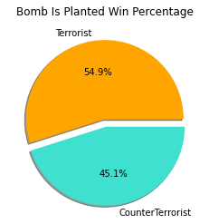

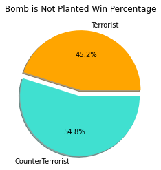

```python
valid_side = ["Terrorist", "CounterTerrorist"]
i = 0
win_loss = []
valid_bomb = ["True", "False"]
# appending the Terrorist and Counter Terrorist bomb is planted win %
for i in range (0,2):
     win_loss.append(kills[kills['win_side'] == valid_side[i]]["is_bomb_planted"].value_counts("True"))
temp = pd.DataFrame(win_loss)
temp
# storing percentages in true and false arrays and graphing in a pie chart
true = [.554348, .455652]
plt.pie(true, labels=valid_side, colors=['orange', 'turquoise'], autopct='%1.1f%%', shadow=true, explode=(0, .1))
plt.title("Bomb Is Planted Win Percentage")
plt.show()
false = [.451620, .548380]
plt.pie(false, labels=valid_side, colors=['orange', 'turquoise'], autopct='%1.1f%%', shadow=true, explode=(0, .1))
plt.title("Bomb is Not Planted Win Percentage")
plt.show()
```

Due to issues in formatting when trying to mix the two databases together, we could not convert the data automatically in pie charts from our raw calculations. Instead we had to see the calculations for ourselves, and manually input those results into workable arrays to create these pie charts.

As seen from these pie charts, when terrorists are able to get a bomb planted within a round, their win percentage spikes from 45.2% to 54.9%. This is a significant increase, and a reasonable wone given that planting the bomb is not the only win condition in a round for terrorists. This backs up our belief that the terrorist team is able to win a higher percentage of rounds that exceed 150 seconds in length due to the fact that the bomb must have been planted in those rounds, as the percentage of rounds won in the 150-180 second range is almost the exact same as the overall percentage of rounds won where terrorists got the bomb planted.

## Map: de_nuke

[figure not shown]

### Round Win Vs. Team Economy

Another factor that we believe is important is the overall money that a team has going into a round. Having stronger equipment and weaponry should in theory give a massive advantage to a team in being able to win a round.

First, we want to test our previous hypothesis that a possible reason for the lower win percentage in faster rounds for terrorists was due to more of these faster paced rounds not being “normal” buy rounds.

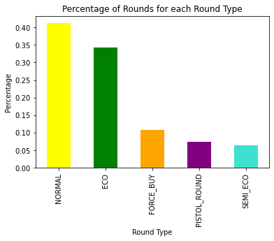

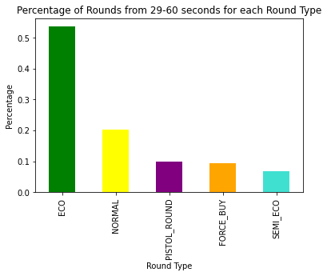

```python
count = []
round_data['round_type'].value_counts(1).plot(kind='bar', title="Percentage of Rounds for each Round Type", xlabel="Round Type", ylabel="Percentage", color=['yellow', 'green', 'orange', 'purple', 'turquoise'])
plt.show()
round_data[round_data["total_time"] < 60]["round_type"].value_counts(1).plot(kind='bar', title="Percentage of Rounds from 29-60 seconds for each Round Type", xlabel="Round Type", ylabel="Percentage", color=['green', 'yellow', 'purple', 'orange', 'turquoise'])
plt.show()
```

From these bar graphs, we can see that in all rounds in our data, normal rounds were the most common, accounting for slightly more than 40 percent of all rounds. Following this was eco rounds at around 35 percent. However, these values are very different when taking into account rounds that were over quickly, ranging from 29-60 seconds, which was a time range that terrorists preformed relatively poorly in. In these rounds, over 50 percent were eco rounds, with only around 20 percent of these rounds being normal buy rounds. Eco rounds accounted for 20 percent more of all rounds from 29-60 seconds, while normal rounds accounted for 20 percent less of these rounds. The much higher proportion of lower buy rounds in rounds that took 29-60 seconds reaffirms our thought that the terrorist win percentage in these round lengths is partially due to the terrorist side having less money in rounds that end up taking a shorter amount of time.

Now, we want to see just how much of an impact the total team economy has on the team’s winning percentage. We will split this analysis up into the Terrorist and Counter Terrorist sides to see if there are any discrepancies in total team economy and round-win percentage across the two sides.

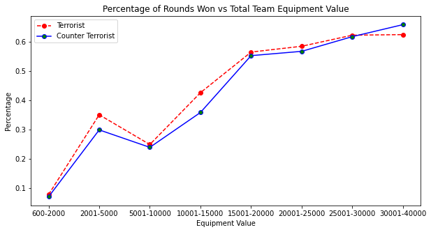

```python
colors = ["green", "orange", "turquoise", "blue", "purple", "red", "yellow", "pink"]
# creating bins representing total equpiment value
bins = [600, 2000, 5000, 10000,15000, 20000, 25000, 30000, 40000]
# grouping each bin together
group_names = ['600-2000', '2001-5000', '5001-10000', '10001-15000', '15001-20000', '20001-25000', '25001-30000', '30001-40000']
# creating column in round_data representing which Terrorist row corresponds to what bin
round_data['t_money_bins'] = pd.cut(round_data['t_eq_val'], bins, labels=group_names)
# creating column in round_data representing which Counter Terrorist row corresponds to what bin
round_data['ct_money_bins'] = pd.cut(round_data['ct_eq_val'], bins, labels=group_names)

i = 0
win = "Terrorist"
categories = []
win_loss = []
win_loss2 = []

# for each bin, append to the win_loss (terrorist) and win_loss2 (counter terrorist) the percentage of rounds
for i in range(0,8):
    categories.append(group_names[i])
    win_loss.append(round_data[round_data['t_money_bins'] == group_names[i]]["winner_side"].value_counts(win))
    win_loss2.append(1 - (round_data[round_data['ct_money_bins'] == group_names[i]]["winner_side"].value_counts("CounterTerrorist")))

filtered_data = pd.DataFrame(win_loss)
filtered_data2 = pd.DataFrame(win_loss2)
plt.figure(figsize = (10,5))
plt.plot(categories, filtered_data[win], linestyle='--', marker='o', color='r', mfc='red', label="Terrorist")
plt.plot(categories, filtered_data2[win], linestyle='-', marker='o', color='b', mfc='green', label="Counter Terrorist")
plt.legend(['Terrorist', 'Counter Terrorist'])
plt.title('Percentage of Rounds Won vs Total Team Equipment Value')
plt.xlabel('Equipment Value')
plt.ylabel('Percentage')
plt.show()
```

From this line chart, we can see that the team economy vs team win percentage is very similar for both teams, with very little notable difference between the two lines. The overall trend is positive, with higher equipment value yielding higher win percentage, which was expected. What was not expected, is how drastic this effect is, with an over 30 percent increase in round win percentage from a total equipment value of 5,001-10,000 (force-buy round) to an equipment value of 15,001-20,000 (normal round). This is the most significant change in win-percentage, much higher than the win-percentage changes from both the round-time and bomb-plant analysis.

Despite the overall upwards trend, there are some interesting features to this graph. Firstly, the upward tendency plateaus around the 25,000 dollar mark, with low gains in win percentage after that mark. This could be due to the fact that 25,000 is a very high amount of money for a team to be able to invest in their equipment, and the net difference from 25,000 dollars to 30,000 might be some extra grenades or secondary equipment, which is relatively much less than the difference between 7,500 and 12,500 which in many cases is a completely different class of gun and being able to afford any equipment at all. A second notable feature is the sudden dip in win percentage that both teams experience from 2,001-5,000 dollars to 5,001-10,000 dollars. This could be due to the fact that when a team has around 3,000 dollars, this is usually early in the game, when the other side probably also has around the same low money, whereas when a team has around 8,000 dollars, the other side probably has significantly more money at their disposal.

Now that it is clear that the total team equipment value is a much larger determiner of round win percentage than round time and if the bomb was planted, we want to try and make a linear regression model based on team win percentage as a function of total team equipment value.

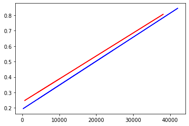

```python
# converting categorical data (Terrorist/CounterTerrorist) to dummy variable
round_data["t_win"] = pd.get_dummies(round_data["winner_side"])["Terrorist"]
round_data["ct_win"] = pd.get_dummies(round_data["winner_side"])["CounterTerrorist"]
round_data

# creating linear regression line for Terrorists and Counter Terrorists
model = LinearRegression()
model2 = LinearRegression()
model.fit(round_data["t_eq_val"].values.reshape(-1,1), round_data["t_win"].values.reshape(-1,1))
model2.fit(round_data["ct_eq_val"].values.reshape(-1,1), round_data["ct_win"].values.reshape(-1,1))
plt.plot(round_data["t_eq_val"], model.coef_[0]*round_data["t_eq_val"]+model.intercept_, color = "red")
plt.plot(round_data["ct_eq_val"], model2.coef_[0]*round_data["ct_eq_val"]+model2.intercept_, color = "blue")

plt.show()
```

Because the winning team is a categorical variable, we could not do a linear regression on that data specifically, we had to one-hot encode the data in order to make it numerical. One hot encoding is a method of transforming categorical data into numerical data by creating a new column for each possible categorical value, and having a 1 if that row contains tha value, and a 0 if not.

More information can be found about how this process works in machine learning here:

https://machinelearningmastery.com/why-one-hot-encode-data-in-machine-learning/

We can see that the linear regression is slightly different for terrorist and counter terrorists, with the win percentage being slightly higher for terrorists given the same team equipment value. Now we want to test the accuracy of our linear regression model.

```python
# using mean_squared_error to determine RMSE for both sides
pred = model.predict(round_data["t_eq_val"].values.reshape(-1,1))
error = math.sqrt(mean_squared_error(round_data["t_win"],pred))
pred2 = model.predict(round_data["ct_eq_val"].values.reshape(-1,1))
error2 = math.sqrt(mean_squared_error(round_data["ct_win"],pred))

print("Terrorist Linear Regression RMSE is: " + str(error))
print("Counter Terrorist Linear Regression RMSE is: " + str(error2))
```

```
Terrorist Linear Regression RMSE is: 0.48242147802286944
Counter Terrorist Linear Regression RMSE is: 0.5493707925034276
```

#### The way we analyzed our models is with an error statistic called RMSE.

[figure not shown]

Essentially RMSE takes the difference between the model’s predicted result, and the actual result, sums the squares of those values for all inputs, and then divides by the total number of input and takes the square root of the value. The result is a final value that represents the overall accuracy for a model.

If you want to learn more about the specifics behind RMSE:

https://www.statisticshowto.com/probability-and-statistics/regression-analysis/rmse-root-mean-square-error/

## Analyzing the Balance of Maps:

In CS:GO, each match is played on one map, of which there are 8 to pick from in this dataset. These maps have a huge variety in their setting, size, and characteristics. Some maps have very open spaces and are very large, such as Overpass, while others are much more cramped and consist of tighter walkways, like Inferno. A map like Mirage, for instance, is known for being very small and having many different connections to different parts, and is almost half the size of a large map like Overpass. Nuke, meanwhile is a vertical map, with the two bomb sites being placed on top of each other on different floors in the facility.

Each map is unique in its own way, and has key differences that cause strategies to be different and for games to play out differently depending on the map. Some maps are much easier for a player to snipe in due to having tight corridors, while other maps are much easier to hide behind cover due to being in an open setting. Due to these differences, it is believed by many players that certain maps are easier to play on certain sides, and that due to the map design, a map is either “terrorist-sided”, “counter-terrorist-sided” or “balanced”. We want to see all the maps’ Terrorist vs. Counter-Terrorist win percentage and see if there are any maps that stand out as having disproportionate balance in it’s win percentage for each side.

First we will graph the terrorist/counter-terrorist win percentage in total, and for each of the 8 maps individually to see if there are any notable differences from the overall. We will do this using the meta_demos dataset from our master database, as it has the map information for each round played.

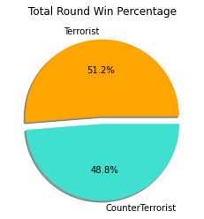

```python
x = len(maps[maps["winner_side"] == "Terrorist"]["winner_side"])
y = len(maps[maps["winner_side"] == "CounterTerrorist"]["winner_side"])
z = [x,y]
# creating pie chart for total round win percentage
plt.pie(z, labels=valid_side, colors=['orange', 'turquoise'], autopct='%1.1f%%', shadow=true, explode=(0, .1))
plt.title("Total Round Win Percentage")
plt.show()
```

From just counting Terrorist vs. Counter Terrorist round wins, we can see Terrorists win around 51 percent of rounds to Counter Terrrorist’s 49 percent. This gives us a baseline to test each individual map to see if any map has a split that is significantly different from the general win percentage.

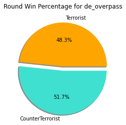

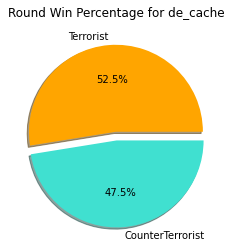

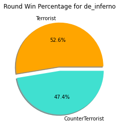

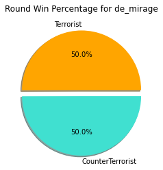

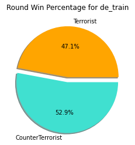

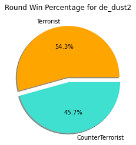

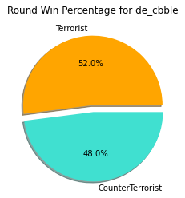

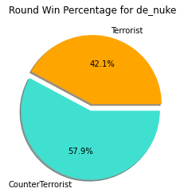

```python
# graphing win percentage for each unique map
for map_name in maps["map"].unique():
    temp = maps[maps["map"] == map_name]
    x = len(temp[temp["winner_side"] == "Terrorist"]["winner_side"])
    y = len(temp[temp["winner_side"] == "CounterTerrorist"]["winner_side"])
    z = [x,y]
    plt.pie(z, labels=valid_side, colors=['orange', 'turquoise'], autopct='%1.1f%%', shadow=true, explode=(0, .1))
    plt.title("Round Win Percentage for " + map_name)
    plt.show()
```

These are pie charts that display the round win percentage for each of the 8 specific maps. Most of these maps seem decently balanced and close to the overall round win percentage pie chart, with Mirage being impressively balanced at almost an exact 50/50 split. However, we can see two maps in particular that do seem to deviate from this balance, with Dust2 boasting the highest Terrorist round win percentage at 54.3 percent, and Nuke boasting the highest Counter Terrorist round win percentage at 57.9 percent.

Dust 2 and Nuke have reputations for being a more terrorist and counter-terrorist sided map respectively. Dust 2’s layout allows the Terrorist side to immediately have a sight-line into the Counter-Terrorist territory, which is generally seen as giving the Terrorists an advantage, while Nuke is known for being cramped, and easier to navigate from the Counter-Terrorist side of the map, which has given it it’s reputation as the most Counter-Terrorist sided map. Even if these pie charts seem to indicate that those reputations are earned, we want to see if these are actually due to the map not being a balanced map, or if these results can be explained through sample variation in our data.

The way that we will test if these results could reasonably be attained if the map was truly 50/50 balanced is through statistical hypothesis testing. Hypothesis testing is a technique that allows you to make a hypothesis, and then test the feasibility of that hypothesis being true or not given the data that you have. In our case, the null hypothesis, or our hypothesis that we will either prove or disprove, is that both Dust 2 and Nuke are 50/50 balanced maps, and that the results we get are explained through sample variation, rather than the maps themselves being unbalanced in nature.

To see the probability of obtaining our results despite the map having a 50/50 round win percentage split, we will use a binomial CDF analysis. This is an analysis that returns the percentage of getting results as or more extreme than the results that were attained in the data. The Binomial CDF function calculates this score based on

```
1. The Number of Successes (rounds won by the team with less overall win percentage)
2. The Number of Trials (total rounds played)
3. The Probability of a Success (.5, if we assume a balanced 50/50 split)
```

For more information about the applications of using Binomial CDF:

https://www.mathworks.com/help/stats/binocdf.html

The percentage scored returned is said to be the “p-value” of the hypothesis test, and generally if this value is .05 or greater, than it is reasonable to assume that the null hypothesis is true, and if the p-value is less than .05, then the null hypothesis is rejected. In our case, this equates to either concluding that the map is balanced and that the results are due to sample variation, or that the map is unbalanced.

```python
# creating variables to enter into binomial distribution formula
temp = maps[maps["map"] == "de_nuke"]
x = len(temp[temp["winner_side"] == "Terrorist"]["winner_side"])
n = len(temp)
p = 0.5
q = 0.5
print("Probability of de_nuke getting round win percentage results this or more extreme than this is: " + str(round(binom.cdf(x,n,p), 1)))

temp = maps[maps["map"] == "de_dust2"]
x = len(temp[temp["winner_side"] == "CounterTerrorist"]["winner_side"])
n = len(temp)
p = 0.5
q = 0.5
print("Probability of de_dust2 getting round win percentage results this or more extreme than this is: " + str(round(binom.cdf(x,n,p), 1)))
print()
```

```
Probability of de_nuke getting round win percentage results this or more extreme than this is: 0.0
Probability of de_dust2 getting round win percentage results this or more extreme than this is: 0.0
```

We rounded our percentage results to the nearest decimal place to neatly display our p-value. Through performing a binomial cdf for both the results of our Nuke and Dust 2 sample data, we can see that the probabilities of obtaining results that are this extreme or more extreme are essentially zero. In order to accept the null hypothesis, the standard accepted p-value is .05, as this is seen as a reasonable percentage to assume that the results can be due to sample variation. However, our p-values are nearly 0 for obtaining these results, which means that we reject the null hypothesis, and therefore we conclude that Dust 2 is in fact terrorist-sided and not balanced, and that Nuke is counter-terrorist sided.

### Bombsite B on de_inferno

[figure not shown]

Given that the p-values for the two most extreme maps in terms of round-win percentage were incredibly low, being nearly 0, this gives us reason to believe that the overall win percentage split that we previously thought indicated that the game as a whole was balanced between the two sides, might actually not be due to sample variance, and might be proof that CS:GO as a whole is not a perfectly balanced game between the terrorist and counter-terrorist sides.

```python
# probability calculation for CS:GO as a whole
x = len(round_data[round_data["winner_side"] == "CounterTerrorist"]["winner_side"])
n = len(round_data)
p = 0.5
q = 0.5
print("Probability of CS:GO getting round win percentage results this or more extreme than this is: " + str(round(binom.cdf(x,n,p), 1)))
print()
```

```
Probability of CS:GO getting round win percentage results this or more extreme than this is: 0.0
```

Our probability calculation for CS:GO as a whole shows that the probability of getting a 51/49 round-win percentage split is almost 0 percent. Therefore, we can conclude that in nature, CS:GO is slightly Terrorist-sided. Even though a 51 percent terrorist win percentage seems very small, given our large sample of data, even this slight difference cannot be explained simply by sample variation. CS:GO is a complicated game, with so many different factors that can impact the overall balancing. From the exact prices of certain weapons, to how much damage they deal, to each of the individual maps and how they are designed, these moving parts combine to make it almost impossible to perfectly balance the game between the Terorrist and Counter-Terrorist sides. Although the round win percentage split in our data shows that there is not a perfect balance in the game, given the difficulty of trying to make the game as balanced as possible a 51-49 percent split is an impressive accomplishment for the developers of CS:GO.

## Conclusion:

CS:GO is a very complicated game, one where there are so many factors and ways to play that it is impossible to perfectly analyze everything. Through our tutorial, we hope that we were able to provide insights on some parts of the game that can explore some interesting conclusions, and maybe encourage people to try the game out and use some of this information in how they play the game. We also hope that we were able to show how to explore and analyze a dataset, and use features of different python libraries to perform interesting evaluations of data. There is room for further exploration in the world of Counter-Strike, both beyond and in the scope of this dataset. There is the possibility of creating models for overall match win percentage, taking into account individual player statistics, and other forms of analysis. We hope that this tutorial was a fun exploration into the game of Counter-Strike and can encourage others to perform their own analysis of data that they find interesting.